# Practical_7

Hasbini Laura

19 octobre 2022

# Supervised learning: Nonlinear Regression

```r
library(MASS)
library(splines)
library(ISLR)
library(tidyverse)
set.seed(45)
```

## Prediction plot

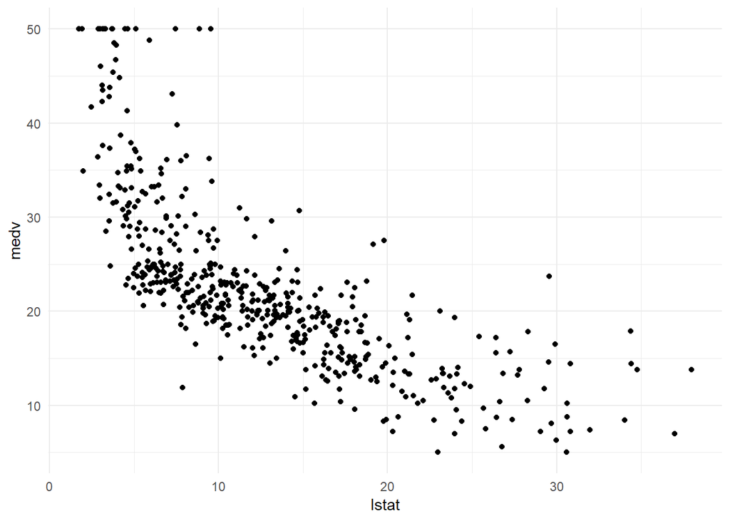

```r
Boston %>%
  ggplot(aes(x = lstat, y = medv)) +
  geom_point() +
  theme_minimal()
```

#### Question 1

“Create a function called pred_plot() that takes as input an lm object, which outputs the above plot but with a prediction line generated from the model object using the predict() method.”

```r
pred_plot <- function(lm_model){
  x_pred <- seq(from=min(Boston$lstat), to=max(Boston$lstat), length.out = 500)
  y_pred <- predict(lm_model, newdata = tibble(lstat = x_pred))
  pred <- tibble(lstat = x_pred, medv=y_pred)

  Boston %>%
    ggplot(aes(x = lstat, y = medv)) +
    geom_point() +
    geom_line(data=pred, size=1, col="blue") +
    theme_minimal()
}
```

#### Question 2

“Create a linear regression object called lin_mod which models medv as a function of lstat. Check if your prediction plot works by running pred_plot(lin_mod). Do you see anything out of the ordinary with the predictions?”

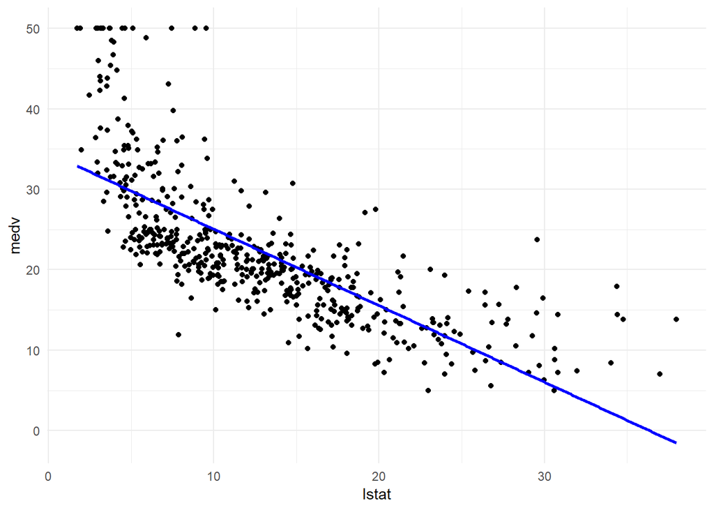

```r
lin_mod <- lm(medv ~ lstat, data = Boston)

pred_plot(lin_mod)
```

The prediction closzly follows the observations, howeve the linearity of the curve imply negative median housing value for high lstat.

#Polynomial regression

#### Question 3

“Create another linear model pn3_mod, where you add the second and third-degree polynomial terms I(lstat^2) and I(lstat^3) to the formula. Create a pred_plot() with this model.”

```r
pn3_mod <- lm(medv ~ lstat + I(lstat^2) + I(lstat^3), data = Boston)

pred_plot(pn3_mod)
```

[output not shown]

#### Question 4

“Play around with the poly() function. What output does it generate with the arguments degree = 3 and raw = TRUE?”

```r
poly(1:5, degree = 3, raw=TRUE)
```

```
##      1  2   3
## [1,] 1  1   1
## [2,] 2  4   8
## [3,] 3  9  27
## [4,] 4 16  64
## [5,] 5 25 125
## attr(,"degree")
## [1] 1 2 3
## attr(,"class")
## [1] "poly"   "matrix"
```

#### Question 5

“Use the poly() function directly in the model formula to create a 3rd-degree polynomial regression predicting medv using lstat. Compare the prediction plot to the previous prediction plot you made. What happens if you change the poly() function to raw = FALSE?”

```r
pn3_mod2 <- lm(medv ~ poly(lstat, degree=3, raw=TRUE), data = Boston)

pred_plot(pn3_mod2)
```

[output not shown]

```r
pn3_mod2 <- lm(medv ~ poly(lstat, degree=3, raw=FALSE), data = Boston)

pred_plot(pn3_mod2)
```

[output not shown]

## Piecewise regression

#### Question 6

“Create a model called pw2_mod with one predictor: I(lstat <= median(lstat)). Create a pred_plot with this model. Use the coefficients in coef(pw2_mod) to find out what the predicted value for a low-lstat neighbourhood is.”

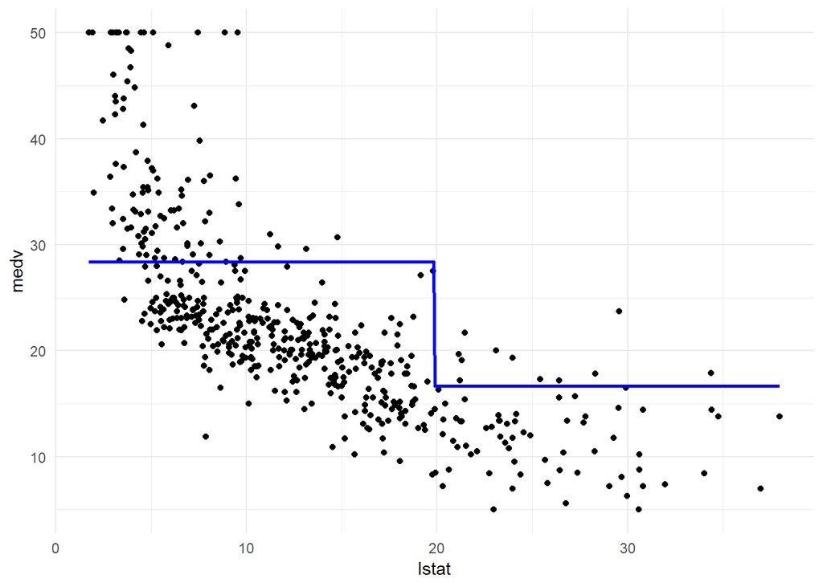

```r
pw2_mod <- lm(medv ~ I(lstat <= median(lstat)), data = Boston)
pred_plot(pw2_mod)
```

```r
coef(pw2_mod)
```

```
##                   (Intercept) I(lstat <= median(lstat))TRUE
##                      16.67747                      11.71067
```

The model above corresponds to a constant piecewise regression. For the low-stat neighbourhood, the predicted value is approwimatly $28.39$

#### Question 7

“Use the cut() function in the formula to generate a piecewise regression model called pw5_mod that contains 5 equally spaced sections. Again, plot the result using pred_plot.”

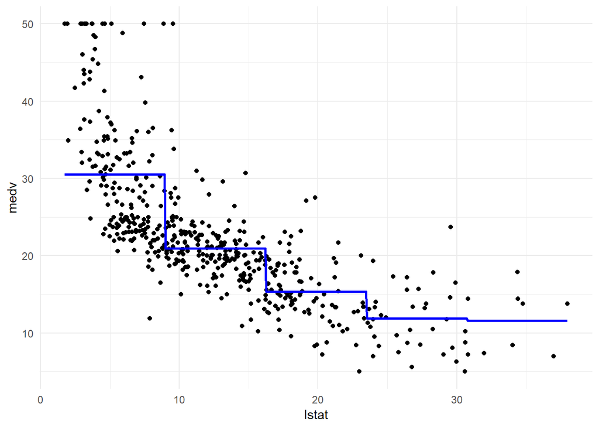

```r
pw5_mod <- lm(medv ~ cut(lstat,5), data = Boston)
pred_plot(pw5_mod)
```

```r
table(cut(Boston$lstat, 5))
```

```
##
## (1.69,8.98] (8.98,16.2] (16.2,23.5] (23.5,30.7]   (30.7,38]
##         183         183          94          37           9
```

When using the function cut we can see that one more time we are constructing a constant piecewise regression, but this time with 5 sections.

#### Question 8

“Optional: Create a piecewise regression model pwq_mod where the sections are not equally spaced, but have equal amounts of training data. Hint: use the quantile() function.”

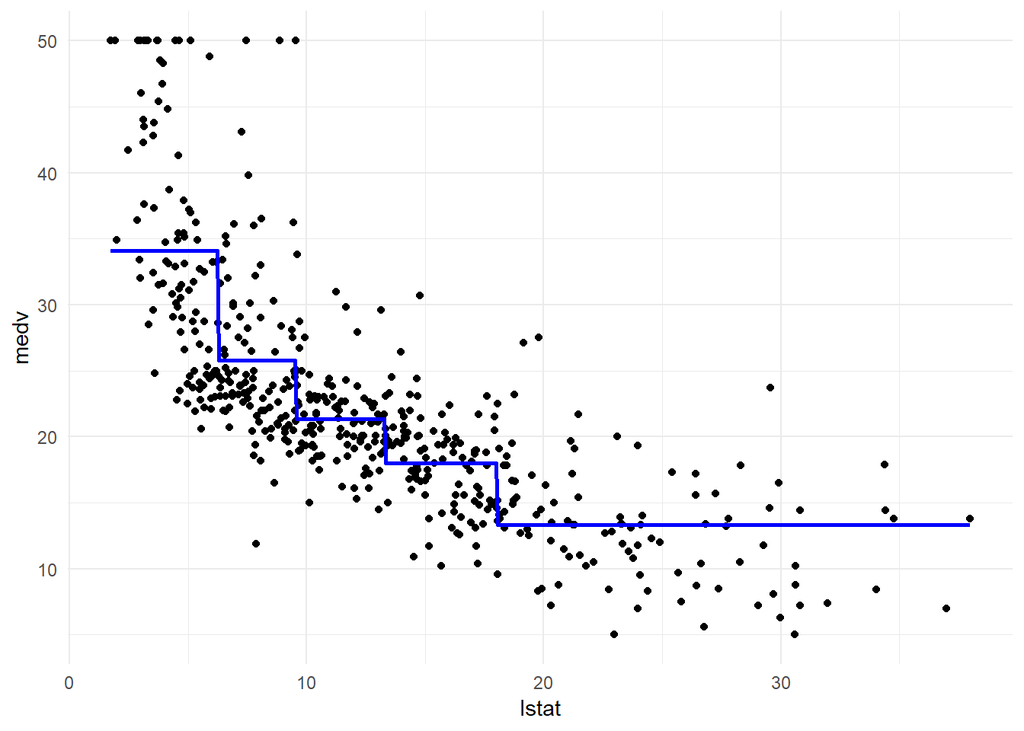

```r
breaks <- c(-Inf, quantile(Boston$lstat, probs = c(0.2, 0.4, 0.6, 0.8)), Inf)
pwq_mod <- lm(medv ~cut(lstat, breaks), data = Boston)
pred_plot(pwq_mod)
```

The piecewise regression seems to performs better when the lstat is cutted regarding the quantiles

## Piecewise polynomial regression

#### Question 9

“This function does not have comments. Copy - paste the function and add comments to each line. To figure out what each line does, you can first create “fake” vec and knots variables, for example vec <- 1:20 and knots <- 2 and try out the lines separately. "

```r
#Creation of a function called 'piecewise_cubis_basis which takes in arguments the vector and the number of regions desired.
piecewise_cubic_basis <- function(vec, knots = 1) {
  #If we don't want any not, a usual regression with a 3th degree polynomial is performed
  if (knots == 0) return(poly(vec, degree = 3, raw = TRUE))

  #Division of the initial vector in K regions
  cut_vec <- cut(vec, breaks = knots + 1)

  #Creation of a matrxi which has no colum the the same number of lines as the original vector
  out <- matrix(nrow = length(vec), ncol = 0)

  #Loop over the K regions of cut_vec
  for (lvl in levels(cut_vec)) {
    tmp <- vec # Copy the original vector in a temporary variable
    tmp[cut_vec != lvl] <- 0 #Assign 0 to all the points out of the region
    out <- cbind(out, poly(tmp, degree = 3, raw = TRUE)) #Save in the matrix out the polynomial regression done on this section
  }

  out
}
```

#### Question 10

“Create piecewise cubic models with 1, 2, and 3 knots (pc1_mod - pc3_mod) using this piecewise cubic basis function. Compare them using the pred_plot() function.”

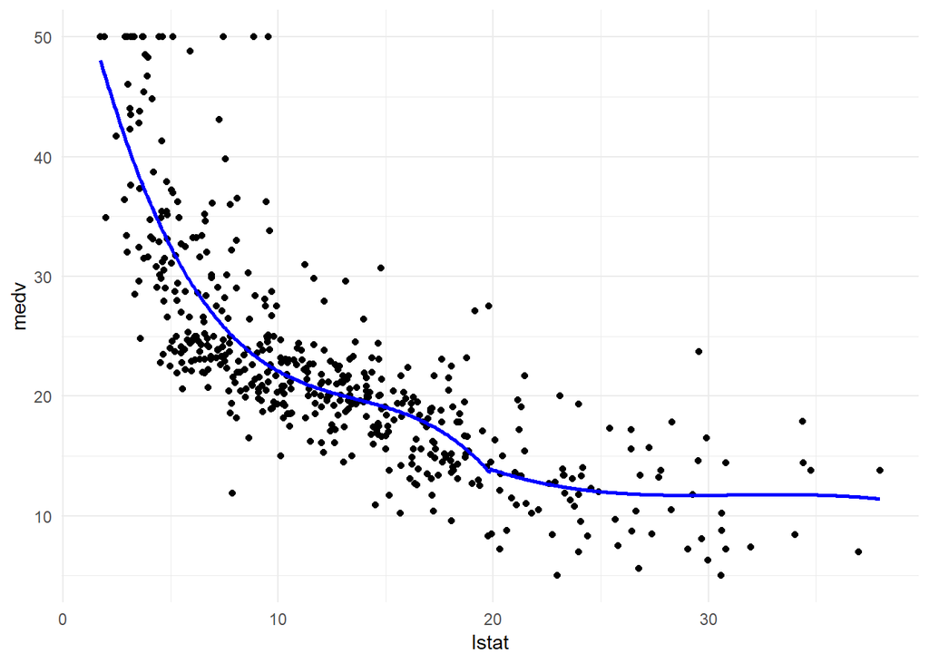

```r
pc1_mod <- lm(medv ~ piecewise_cubic_basis(lstat, 1), data=Boston)
pred_plot(pc1_mod)
```

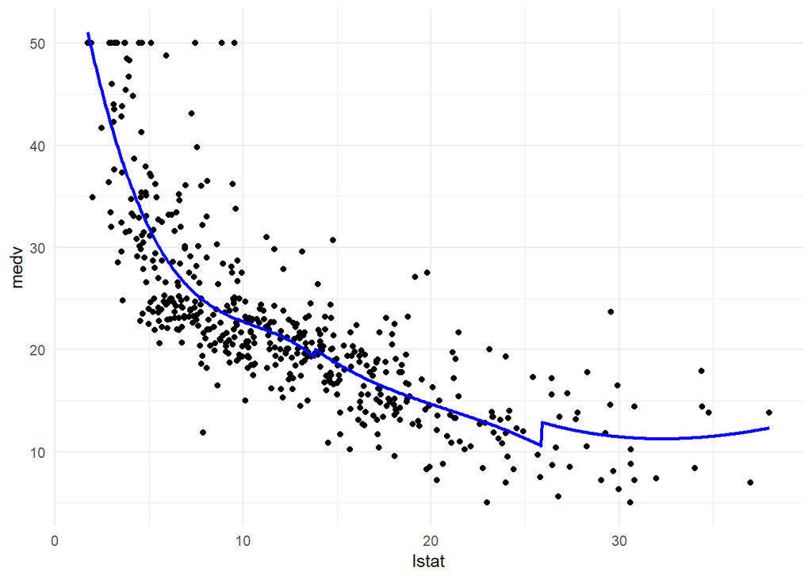

```r
pc2_mod <- lm(medv ~ piecewise_cubic_basis(lstat, 2), data=Boston)
pred_plot(pc2_mod)
```

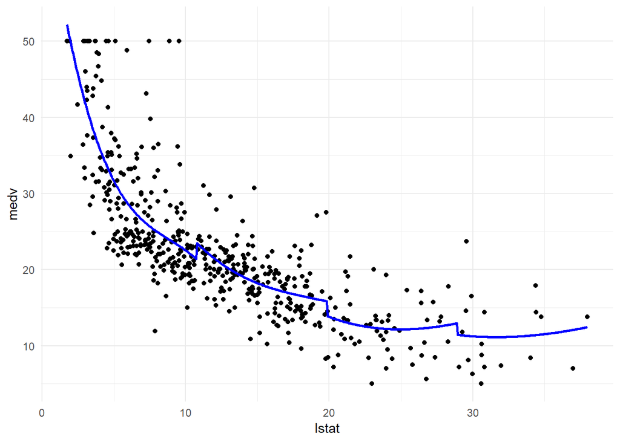

```r
pc3_mod <- lm(medv ~ piecewise_cubic_basis(lstat, 3), data=Boston)
pred_plot(pc3_mod)
```

When increasing the number of note it seems that the prediction is closer to the original data on each section. However, as we didn’t add any constraint on continuity, $1^{st}$ and $2^{nd}$ order derivative, we can also see some jumps between the sections. Overall we can thus deduce that the best options are either to constrain continuity or to choose only 1/2 section.

## Splines

#### Question 11

“Create a data frame called boston_tpb with the columns medv and lstat from the Boston dataset.”

```r
boston_tpb <- tibble(medv = Boston$medv, lstat = Boston$lstat)
```

#### Question 12

“Now use mutate to add squared and cubed versions of the lstat variable to this dataset.”

```r
boston_tpb <- boston_tpb %>% mutate(lstat2 = I(lstat^2),
                      lstat3 = I(lstat^3))
```

#### Question 13

“Use mutate to add a column lstat_tpb to this dataset which is 0 below the median and has value (lstat - median(lstat))^3 above the median. Tip: you may want to use ifelse() within your mutate() call.”

```r
boston_tpb <- boston_tpb %>% mutate(lstat_tpb = ifelse(lstat<median(lstat), 0, (lstat - median(lstat))^3))
```

#### Question 14

“Create a linear model tpb_mod using the lm() function. How many predictors are in the model? How many degrees of freedom does this model have?”

```r
tpb_mod <- lm(medv ~ ., data = boston_tpb)
```

This model has 5 predictors : Intercept, lstat, lstat^2, lstat^3 and lstat_tpb and 5 degree of freedom.

#### Question 15

“Create a cubic spline model bs1_mod with a knot at the median using the bs() function. Compare its predictions to those of the tpb_mod using the predict() function on both models.”

```r
bs1_mod <- lm(medv ~ bs(lstat, knots = median(lstat)), data = Boston)
```

```r
mean(abs(predict(bs1_mod)-predict(tpb_mod)))
```

```
## [1] 5.058053e-14
```

The difference between the two models is extremely small, thus suggesting that they have similar performances.

#### Question 16

“Create a prediction plot from the bs1_mod object using the plot_pred() function.”

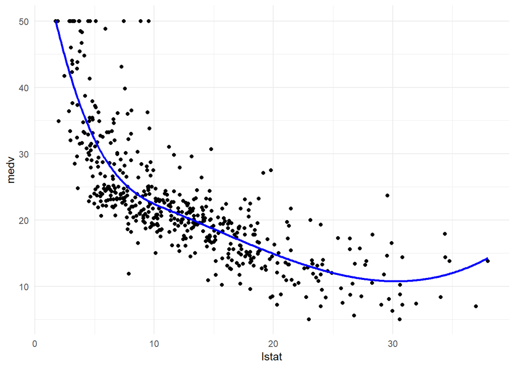

```r
pred_plot(bs1_mod)
```

The models seems to performs really well except for high lstat where the line slopes up

#### Question 17

“Create a natural cubic spline model (ns3_mod) with 3 degrees of freedom using the ns() function. Plot it, and compare it to the bs1_mod.”

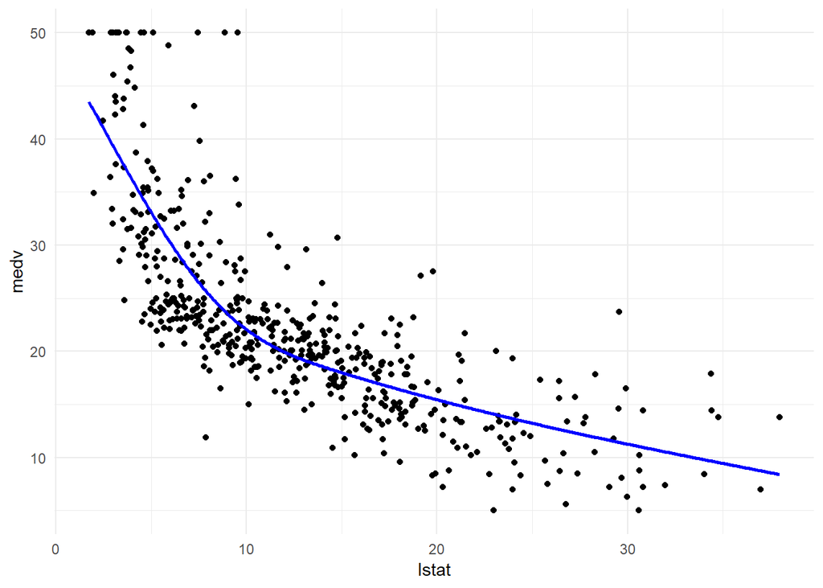

```r
ns3_mod <- lm(medv ~ns(lstat, df=3), data = Boston)
pred_plot(ns3_mod)
```

The fit seems to performs overall less well than bs1. However, it’s physically more accurate as the curve is not increasing again for high lstat.

#### Question 18

“Plot lin_mod, pn3_mod, pw5_mod, pc3_mod, bs1_mod, and ns3_mod and give them nice titles by adding + ggtitle(”My title“) to the plot. You may use the function plot_grid() from the package cowplot to put your plots in a grid.”

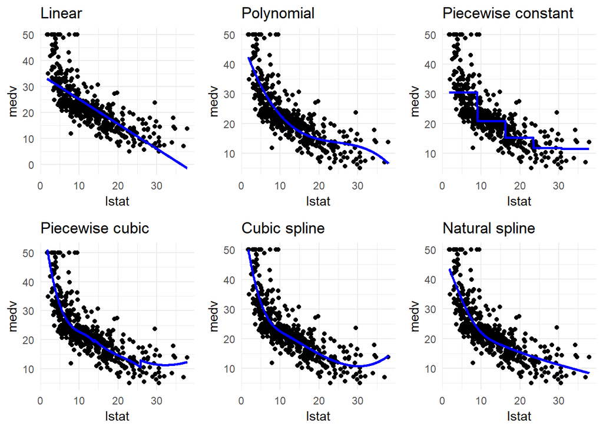

```r
lin_plot <- pred_plot(lin_mod) + ggtitle("Linear")
pn2_plot <- pred_plot(pn3_mod) + ggtitle("Polynomial")
pw5_plot <- pred_plot(pw5_mod) + ggtitle("Piecewise constant")
pc2_plot <- pred_plot(pc2_mod) + ggtitle("Piecewise cubic")
bs1_plot <- pred_plot(bs1_mod) + ggtitle("Cubic spline")
ns3_plot <- pred_plot(ns3_mod) + ggtitle("Natural spline")

cowplot::plot_grid(lin_plot, pn2_plot, pw5_plot, pc2_plot, bs1_plot, ns3_plot)
```

## Programming assignment

#### Question 19

“Use 12-fold cross validation to determine which of the 6 methods (lin, pn3, pw5, pc3, bs1, and ns3) has the lowest out-of-sample MSE.”

```r
mse <- function(y_true, y_pred){mean((y_true-y_pred)^2)}

boston_cv <- Boston %>% mutate(split = sample(rep(1:12, length.out=length(Boston$lstat))))

#The following matrix will return the score obtained for each meathod on each K validation set.
output_matrix <- matrix(nrow=12, ncol=6)
colnames(output_matrix) <- c("lin", "pn3", "pw5", "pc3", "bs1", "ns3")

#Loop to compute the score
for(i in 1:12){
  train <- boston_cv %>% filter(split !=i)
  test <- boston_cv %>% filter(split == i)

  breaks <- c(-Inf, 7, 15, 22, Inf)

  lin_mod <- lm(medv ~lstat, data = train)
  pn3_mod <- lm(medv ~poly(lstat,3), data = train)
  pw5_mod <- lm(medv ~cut(lstat,breaks), data = train)
  pc3_mod <- lm(medv ~piecewise_cubic_basis(lstat,3), data = train)
  bs1_mod <- lm(medv ~bs(lstat, knots=median(lstat)), data = train)
  ns3_mod <- lm(medv ~ns(lstat, df=3), data = train)

  scores = c(mse(test$medv, predict(lin_mod, newdata = test)),
            mse(test$medv, predict(pn3_mod, newdata = test)),
            mse(test$medv, predict(pw5_mod, newdata = test)),
            mse(test$medv, predict(pc3_mod, newdata = test)),
            mse(test$medv, predict(bs1_mod, newdata = test)),
            mse(test$medv, predict(ns3_mod, newdata = test)))
  output_matrix[i, ] <- scores

}
colMeans(output_matrix)
```

```
##      lin      pn3      pw5      pc3      bs1      ns3
## 38.76726 29.36707 37.95038 29.22791 27.51021 28.68858
```